# Final Projecct

Tasleem Moossun

2023-04-28

## Descriptive Exloratory Analysis

Before diving into deeper analysis and modeling, it is essential to perform Descriptive (Exploratory) Tasks to gain a solid understanding of the data set and its underlying structure.

1. Identifying potential data quality issues, such as missing values, outliers, and errors, which may negatively impact the performance of machine learning models.

Here are the steps that I have taken for the Descriptive analysis:

1. I have removed the URL column from the data frame as it was not providing additional predictive power to any models and it was not possible to turn it in factor variable as well.
2. The missing values have also been removed from the data frame using complete cases
3. Any character variables have then been converted to factor variables
4. Because I will later be using a linear model and a logistic model, I have decided to remove the variables that have a high correlation factor. I have therefore set a threshold of 0.7 and any variables that have a correlation factor above 0.7 are then removed from the data frame. This will help with multi-collinearity.
5. Then I have attempted to identify the outliers in the df - Since the models such as randomForest, gbm usually takes care of outliers, I will not be removing them from the df.

```r
library(readr)
library(corrplot)
library(caret)
OnlineNewsPopularity <- read_csv("OnlineNewsPopularity.csv")
df <- OnlineNewsPopularity

str(df)
```

```
## spc_tbl_ [39,644 × 61] (S3: spec_tbl_df/tbl_df/tbl/data.frame)
##  $ url                          : chr [1:39644] "http://mashable.com/2013/01/07/amazon-instant-video-browser/" "http://mashable.com/2013/01/07/ap-samsung-sponsored-tweets/" "http://mashable.com/2013/01/07/apple-40-billion-app-downloads/" "http://mashable.com/2013/01/07/astronaut-notre-dame-bcs/" …
##  $ timedelta                    : num [1:39644] 731 731 731 731 731 731 731 731 731 731 ...
##  $ n_tokens_title               : num [1:39644] 12 9 9 9 13 10 8 12 11 10 ...
##  $ n_tokens_content             : num [1:39644] 219 255 211 531 1072 ...
##  $ n_unique_tokens              : num [1:39644] 0.664 0.605 0.575 0.504 0.416 ...
##  $ n_non_stop_words             : num [1:39644] 1 1 1 1 1 ...
##  $ n_non_stop_unique_tokens     : num [1:39644] 0.815 0.792 0.664 0.666 0.541 ...
##  $ num_hrefs                    : num [1:39644] 4 3 3 9 19 2 21 20 2 4 ...
##  $ num_self_hrefs               : num [1:39644] 2 1 1 0 19 2 20 20 0 1 ...
##  $ num_imgs                     : num [1:39644] 1 1 1 1 20 0 20 20 0 1 ...
##  $ num_videos                   : num [1:39644] 0 0 0 0 0 0 0 0 0 1 ...
##  $ average_token_length         : num [1:39644] 4.68 4.91 4.39 4.4 4.68 ...
##  $ num_keywords                 : num [1:39644] 5 4 6 7 7 9 10 9 7 5 ...
##  $ data_channel_is_lifestyle    : num [1:39644] 0 0 0 0 0 0 1 0 0 0 ...
##  $ data_channel_is_entertainment: num [1:39644] 1 0 0 1 0 0 0 0 0 0 ...
##  $ data_channel_is_bus          : num [1:39644] 0 1 1 0 0 0 0 0 0 0 ...
##  $ data_channel_is_socmed       : num [1:39644] 0 0 0 0 0 0 0 0 0 0 ...
##  $ data_channel_is_tech         : num [1:39644] 0 0 0 0 1 1 0 1 1 0 ...
##  $ data_channel_is_world        : num [1:39644] 0 0 0 0 0 0 0 0 0 1 ...
##  $ kw_min_min                   : num [1:39644] 0 0 0 0 0 0 0 0 0 0 ...
##  $ kw_max_min                   : num [1:39644] 0 0 0 0 0 0 0 0 0 0 ...
##  $ kw_avg_min                   : num [1:39644] 0 0 0 0 0 0 0 0 0 0 ...
##  $ kw_min_max                   : num [1:39644] 0 0 0 0 0 0 0 0 0 0 ...
##  $ kw_max_max                   : num [1:39644] 0 0 0 0 0 0 0 0 0 0 ...
##  $ kw_avg_max                   : num [1:39644] 0 0 0 0 0 0 0 0 0 0 ...
##  $ kw_min_avg                   : num [1:39644] 0 0 0 0 0 0 0 0 0 0 ...
##  $ kw_max_avg                   : num [1:39644] 0 0 0 0 0 0 0 0 0 0 ...
##  $ kw_avg_avg                   : num [1:39644] 0 0 0 0 0 0 0 0 0 0 ...
##  $ self_reference_min_shares    : num [1:39644] 496 0 918 0 545 8500 545 545 0 0 ...
##  $ self_reference_max_shares    : num [1:39644] 496 0 918 0 16000 8500 16000 16000 0 0 ...
##  $ self_reference_avg_sharess   : num [1:39644] 496 0 918 0 3151 ...
##  $ weekday_is_monday            : num [1:39644] 1 1 1 1 1 1 1 1 1 1 ...
##  $ weekday_is_tuesday           : num [1:39644] 0 0 0 0 0 0 0 0 0 0 ...
##  $ weekday_is_wednesday         : num [1:39644] 0 0 0 0 0 0 0 0 0 0 ...
##  $ weekday_is_thursday          : num [1:39644] 0 0 0 0 0 0 0 0 0 0 ...
##  $ weekday_is_friday            : num [1:39644] 0 0 0 0 0 0 0 0 0 0 ...
##  $ weekday_is_saturday          : num [1:39644] 0 0 0 0 0 0 0 0 0 0 ...
##  $ weekday_is_sunday            : num [1:39644] 0 0 0 0 0 0 0 0 0 0 ...
##  $ is_weekend                   : num [1:39644] 0 0 0 0 0 0 0 0 0 0 ...
```

[output cut: 72 more lines]

```
##   ..   rate_positive_words = col_double(),
##   ..   rate_negative_words = col_double(),
##   ..   avg_positive_polarity = col_double(),
##   ..   min_positive_polarity = col_double(),
##   ..   max_positive_polarity = col_double(),
##   ..   avg_negative_polarity = col_double(),
##   ..   min_negative_polarity = col_double(),
##   ..   max_negative_polarity = col_double(),
##   ..   title_subjectivity = col_double(),
##   ..   title_sentiment_polarity = col_double(),
##   ..   abs_title_subjectivity = col_double(),
##   ..   abs_title_sentiment_polarity = col_double(),
##   ..   shares = col_double()
##   .. )
##  - attr(*, "problems")=<externalptr>
```

```r
df2 <- subset(df, select = -url)

which(is.na(df2))
```

```
## integer(0)
```

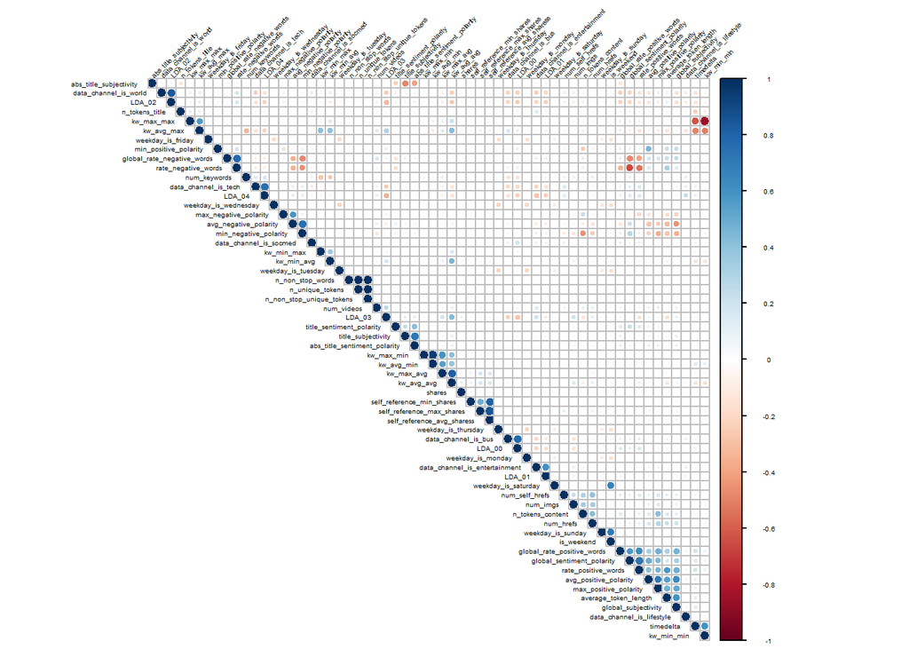

```r
df2 <- df2[complete.cases(df2), ]

for (i in 1:ncol(df2)) {
  if(is.character(df2[, i])) df[,i] <- as.factor(df2[,i])
}

# Calculate correlation matrix
corr_matrix <- cor(df2)

# Visualize correlation matrix
corrplot(corr_matrix, type = "upper", method = "circle", order = "hclust", tl.col = "black",tl.cex = 0.3, cl.cex = 0.3, tl.srt = 45)
```

```r
# Set the correlation threshold
threshold <- 0.7

# Identify highly correlated variables
highly_correlated <- findCorrelation(corr_matrix, cutoff = threshold)

# Print the index of highly correlated variables
cat("Highly correlated variables:\n")
```

```
## Highly correlated variables:
```

```r
print(highly_correlated)
```

```
##  [1] 48 27 50 18 54 49 43 39 23 59 38 30 20  4  5
```

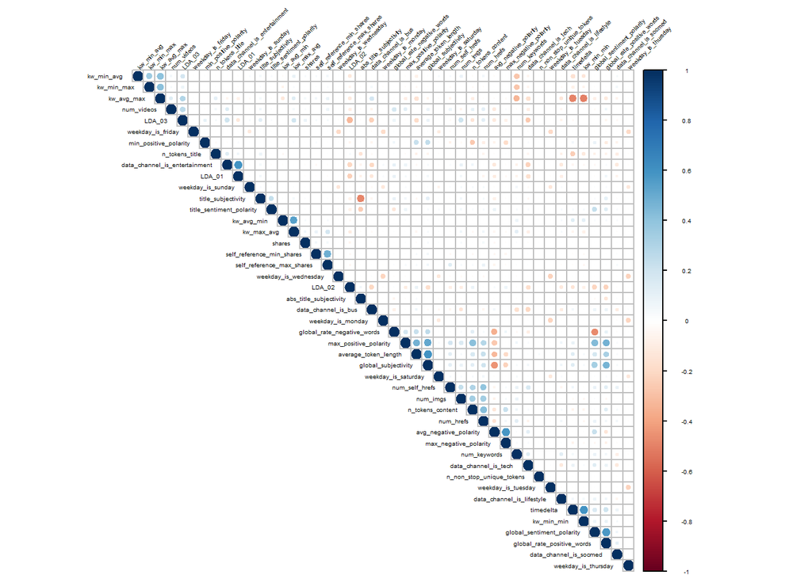

```r
# Remove highly correlated variables from the dataframe
df2_cleaned <- df2[, -highly_correlated]

# Recalculate the correlation matrix for the cleaned data
corr_matrix_cleaned <- cor(df2_cleaned)

# Visualize the cleaned correlation matrix
corrplot(corr_matrix_cleaned, type = "upper", method = "circle", order = "hclust", tl.col = "black", tl.cex = 0.3, cl.cex = 0.3, tl.srt = 45)
```

```r
# Function to detect outliers
find_outliers <- function(x) {
  quartiles <- quantile(x, c(.25, .75))
  iqr <- IQR(x)
  outliers <- x < (quartiles[1] - 1.5 * iqr) | x > (quartiles[2] + 1.5 * iqr)
  return(outliers)
}

# Apply the function to each column of df2_cleaned
outliers <- apply(df2_cleaned, 2, find_outliers)

# Print columns with outliers
outlier_columns <- colnames(df2_cleaned)[apply(outliers, 2, any)]

cat("Columns with outliers:\n")
```

```
## Columns with outliers:
```

```r
print(outlier_columns)
```

```
##  [1] "n_tokens_title"                "n_tokens_content"
##  [3] "n_non_stop_unique_tokens"      "num_hrefs"
##  [5] "num_self_hrefs"                "num_imgs"
##  [7] "num_videos"                    "average_token_length"
##  [9] "num_keywords"                  "data_channel_is_lifestyle"
## [11] "data_channel_is_entertainment" "data_channel_is_bus"
## [13] "data_channel_is_socmed"        "data_channel_is_tech"
## [15] "kw_min_min"                    "kw_avg_min"
## [17] "kw_min_max"                    "kw_avg_max"
## [19] "kw_max_avg"                    "self_reference_min_shares"
## [21] "self_reference_max_shares"     "weekday_is_monday"
## [23] "weekday_is_tuesday"            "weekday_is_wednesday"
## [25] "weekday_is_thursday"           "weekday_is_friday"
## [27] "weekday_is_saturday"           "weekday_is_sunday"
## [29] "LDA_01"                        "LDA_02"
## [31] "LDA_03"                        "global_subjectivity"
## [33] "global_sentiment_polarity"     "global_rate_positive_words"
## [35] "global_rate_negative_words"    "min_positive_polarity"
## [37] "avg_negative_polarity"         "max_negative_polarity"
## [39] "title_sentiment_polarity"      "shares"
```

2. Explore the relationships between pairs of features.a In the context of the Online News Popularity dataset, produce: • Summary statistics table: A table showing summary statistics (mean, median, standard deviation, minimum, and maximum) for all continuous features in the dataset. This table will provide an overview of the central tendency and dispersion of the data, making it easier to understand the general characteristics of the dataset. • Popularity categories distribution table: A table displaying the frequency distribution of articles categorized into ‘popular’ and ‘non-popular’ classes based on the predefined threshold. This table will help assess the balance between the two classes and provide insights into the overall popularity of articles in the dataset. • Data channels distribution table: A table illustrating the frequency distribution of articles across different data channels (Lifestyle, Entertainment, Business, Social Media, Technology, and World). This table will provide insights into the prominence of various topics in the dataset and their potential impact on article popularity. • Weekday distribution table: A table presenting the frequency distribution of articles published on different weekdays (Monday, Tuesday, Wednesday, Thursday, Friday, Saturday, and Sunday). This table will help analyze the influence of publication day on article popularity and identify any trends or patterns related to weekdays. A table illustrating the frequency distribution of articles published on different weekdays (Monday through Sunday).

This table aids in analyzing the influence of publication day on article popularity and identifying trends or patterns related to weekdays. You may perform cross-tabulation in relation to data channels and/or popularity categories. These tables will contribute to a deeper understanding of the dataset and its underlying structure, guiding your feature selection and modeling choices. Furthermore, they offer valuable insights into factors that could influence the popularity of news articles on Mashable. When presenting these tables in your HTML or PDF files, consider using various packages that enhance the appearance and readability of tables. By ensuring a visually appealing presentation, you can effectively communicate the information and insights derived from the dataset to your audience.

3. Descriptive tasks often involve visualizations, which can help communicate your findings more effectively to your audience. Visualizations enable stakeholders to grasp complex patterns and relationships more easily, making it an essential part of any data analysis project. Use ggplot to plot the last 3 tables described above

```r
library(ggplot2)
summary(df2$shares)
```

```
##    Min. 1st Qu.  Median    Mean 3rd Qu.    Max.
##       1     946    1400    3395    2800  843300
```

```r
summary_stats_table <- data.frame(
feature = colnames(df2_cleaned),
mean = sapply(df2_cleaned, mean, na.rm = TRUE),
median = sapply(df2_cleaned, median, na.rm = TRUE),
sd = sapply(df2_cleaned, sd, na.rm = TRUE),
min = sapply(df2_cleaned, min, na.rm = TRUE),
max = sapply(df2_cleaned, max, na.rm = TRUE)
)

print(summary_stats_table)
```

```
##                                                     feature          mean
## timedelta                                         timedelta  3.545305e+02
## n_tokens_title                               n_tokens_title  1.039875e+01
## n_tokens_content                           n_tokens_content  5.465147e+02
## n_non_stop_unique_tokens           n_non_stop_unique_tokens  6.891754e-01
## num_hrefs                                         num_hrefs  1.088369e+01
## num_self_hrefs                               num_self_hrefs  3.293638e+00
## num_imgs                                           num_imgs  4.544143e+00
## num_videos                                       num_videos  1.249874e+00
## average_token_length                   average_token_length  4.548239e+00
## num_keywords                                   num_keywords  7.223767e+00
## data_channel_is_lifestyle         data_channel_is_lifestyle  5.294622e-02
## data_channel_is_entertainment data_channel_is_entertainment  1.780093e-01
## data_channel_is_bus                     data_channel_is_bus  1.578549e-01
## data_channel_is_socmed               data_channel_is_socmed  5.859651e-02
## data_channel_is_tech                   data_channel_is_tech  1.852992e-01
## kw_min_min                                       kw_min_min  2.610680e+01
## kw_avg_min                                       kw_avg_min  3.123670e+02
## kw_min_max                                       kw_min_max  1.361235e+04
## kw_avg_max                                       kw_avg_max  2.592819e+05
## kw_min_avg                                       kw_min_avg  1.117147e+03
## kw_max_avg                                       kw_max_avg  5.657211e+03
## self_reference_min_shares         self_reference_min_shares  3.998755e+03
## self_reference_max_shares         self_reference_max_shares  1.032921e+04
## weekday_is_monday                         weekday_is_monday  1.680204e-01
## weekday_is_tuesday                       weekday_is_tuesday  1.864090e-01
## weekday_is_wednesday                   weekday_is_wednesday  1.875441e-01
## weekday_is_thursday                     weekday_is_thursday  1.833064e-01
## weekday_is_friday                         weekday_is_friday  1.438049e-01
## weekday_is_saturday                     weekday_is_saturday  6.187569e-02
## weekday_is_sunday                         weekday_is_sunday  6.903945e-02
## LDA_01                                               LDA_01  1.412558e-01
## LDA_02                                               LDA_02  2.163210e-01
## LDA_03                                               LDA_03  2.237696e-01
## global_subjectivity                     global_subjectivity  4.433702e-01
## global_sentiment_polarity         global_sentiment_polarity  1.193093e-01
## global_rate_positive_words       global_rate_positive_words  3.962483e-02
## global_rate_negative_words       global_rate_negative_words  1.661212e-02
## min_positive_polarity                 min_positive_polarity  9.544554e-02
## max_positive_polarity                 max_positive_polarity  7.567275e-01
```

[output cut: 37 more lines]

```
## LDA_01                         3.334503e-02 2.197073e-01  0.00000 9.259470e-01
## LDA_02                         4.000394e-02 2.821452e-01  0.00000 9.199991e-01
## LDA_03                         4.000072e-02 2.951907e-01  0.00000 9.265338e-01
## global_subjectivity            4.534573e-01 1.166846e-01  0.00000 1.000000e+00
## global_sentiment_polarity      1.191168e-01 9.693066e-02 -0.39375 7.278409e-01
## global_rate_positive_words     3.902278e-02 1.742866e-02  0.00000 1.554878e-01
## global_rate_negative_words     1.533742e-02 1.082779e-02  0.00000 1.849315e-01
## min_positive_polarity          1.000000e-01 7.131493e-02  0.00000 1.000000e+00
## max_positive_polarity          8.000000e-01 2.477857e-01  0.00000 1.000000e+00
## avg_negative_polarity         -2.533333e-01 1.277257e-01 -1.00000 0.000000e+00
## max_negative_polarity         -1.000000e-01 9.537298e-02 -1.00000 0.000000e+00
## title_subjectivity             1.500000e-01 3.242474e-01  0.00000 1.000000e+00
## title_sentiment_polarity       0.000000e+00 2.654502e-01 -1.00000 1.000000e+00
## abs_title_subjectivity         5.000000e-01 1.887908e-01  0.00000 5.000000e-01
## shares                         1.400000e+03 1.162695e+04  1.00000 8.433000e+05
```

```r
# Define the threshold for popularity
popularity_threshold <- 1400

# Create a binary variable 'is_popular' based on the threshold
df2_cleaned$is_popular <- ifelse(df2_cleaned$shares >= popularity_threshold, "popular", "non-popular")

# Create a frequency distribution table for the 'is_popular' variable
frequency_table <- table(df2_cleaned$is_popular)

# Print the frequency distribution table
print(frequency_table)
```

```
##
## non-popular     popular
##       18490       21154
```

```r
#changing is_popular from character to numeric
for (i in 1:ncol(df2_cleaned)) {
  if(is.character(df2_cleaned[, i])) df[,i] <- as.factor(df2_cleaned[,i])
}

#frequency table

# Identify the data channel columns in the dataset
data_channel_cols <- grep("data_channel_is_", colnames(df2_cleaned), value = TRUE)

# Create a new column 'data_channel' and initialize it with 'Unknown'
df2_cleaned$data_channel <- "Unknown"

# For each article, find the data channel it belongs to
for (col in data_channel_cols) {
  channel_name <- gsub("data_channel_is_", "", col)
  df2_cleaned$data_channel[df2_cleaned[[col]] == 1] <- channel_name
}

# Create a frequency distribution table for the 'data_channel' variable
data_channels_frequency_table <- table(df2_cleaned$data_channel)

# Print the data channels distribution table
print(data_channels_frequency_table)
```

```
##
##           bus entertainment     lifestyle        socmed          tech
##          6258          7057          2099          2323          7346
##       Unknown
##         14561
```

```r
# Identify the weekday columns in the dataset
weekday_cols <- grep("weekday_is_", colnames(df2_cleaned), value = TRUE)

# Create a new column 'weekday' and initialize it with 'Unknown'
df2_cleaned$weekday <- "Unknown"

# For each article, find the weekday it was published on
for (col in weekday_cols) {
  weekday_name <- gsub("weekday_is_", "", col)
  df2_cleaned$weekday[df2_cleaned[[col]] == 1] <- weekday_name
}

# Create a frequency distribution table for the 'weekday' variable
weekday_frequency_table <- table(df2_cleaned$weekday)

# Print the weekday distribution table
print(weekday_frequency_table)
```

```
##
##    friday    monday  saturday    sunday  thursday   tuesday wednesday
##      5701      6661      2453      2737      7267      7390      7435
```

```r
# Cross-tabulation with data channels
cross_tab_data_channels <- table(df2_cleaned$weekday, df2_cleaned$data_channel)
print(cross_tab_data_channels)
```

```
##
##              bus entertainment lifestyle socmed tech Unknown
##   friday     832           972       305    332  989    2271
##   monday    1153          1358       322    337 1235    2256
##   saturday   243           380       182    180  525     943
##   sunday     343           536       210    137  396    1115
##   thursday  1234          1231       358    463 1310    2671
##   tuesday   1182          1285       334    458 1474    2657
##   wednesday 1271          1295       388    416 1417    2648
```

```r
# Cross-tabulation with popularity categories
cross_tab_popularity <- table(df2_cleaned$weekday, df2_cleaned$is_popular)
print(cross_tab_popularity)
```

```
##
##             non-popular popular
##   friday           2588    3113
##   monday           3270    3391
##   saturday          625    1828
##   sunday            856    1881
##   thursday         3598    3669
##   tuesday          3739    3651
##   wednesday        3814    3621
```

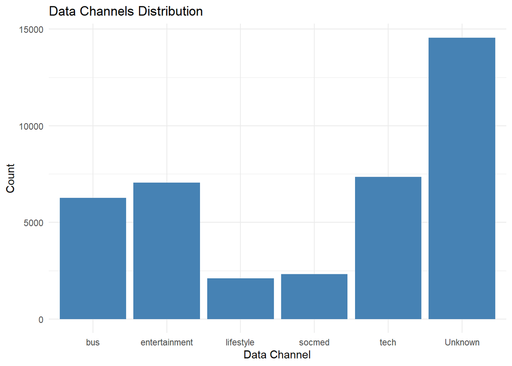

```r
# Convert the frequency tables and cross-tabulations into data frames
data_channels_df <- as.data.frame(data_channels_frequency_table)
colnames(data_channels_df) <- c("data_channel", "count")

weekday_df <- as.data.frame(weekday_frequency_table)
colnames(weekday_df) <- c("weekday", "count")

cross_tab_data_channels_df <- as.data.frame(cross_tab_data_channels)
colnames(cross_tab_data_channels_df) <- c("weekday", "data_channel", "count")

cross_tab_popularity_df <- as.data.frame(cross_tab_popularity)
colnames(cross_tab_popularity_df) <- c("weekday", "is_popular", "count")

# Plot the data channels distribution using ggplot2
data_channels_plot <- ggplot(data_channels_df, aes(x = data_channel, y = count)) +
  geom_bar(stat = "identity", fill = "steelblue") +
  theme_minimal() +
  labs(title = "Data Channels Distribution", x = "Data Channel", y = "Count")
print(data_channels_plot)
```

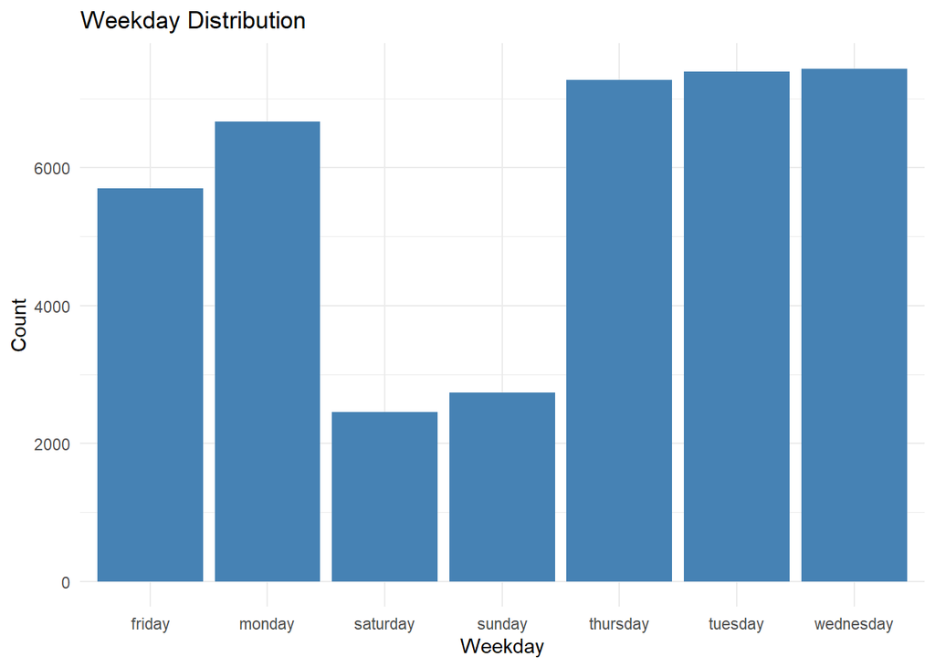

```r
# Plot the weekday distribution using ggplot2
weekday_plot <- ggplot(weekday_df, aes(x = weekday, y = count)) +
  geom_bar(stat = "identity", fill = "steelblue") +
  theme_minimal() +
  labs(title = "Weekday Distribution", x = "Weekday", y = "Count")
print(weekday_plot)
```

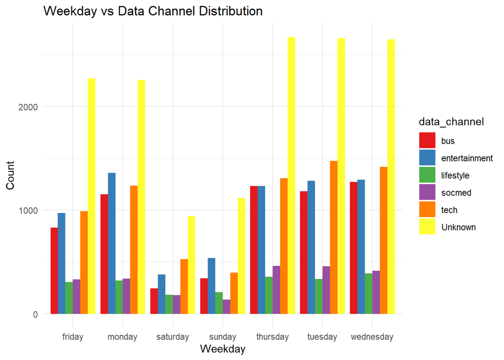

```r
# Plot the cross-tabulation of weekdays and data channels using ggplot2
cross_tab_data_channels_plot <- ggplot(cross_tab_data_channels_df, aes(x = weekday, y = count, fill = data_channel)) +
  geom_bar(stat = "identity", position = "dodge") +
  theme_minimal() +
  labs(title = "Weekday vs Data Channel Distribution", x = "Weekday", y = "Count") +
  scale_fill_brewer(palette = "Set1")
print(cross_tab_data_channels_plot)
```

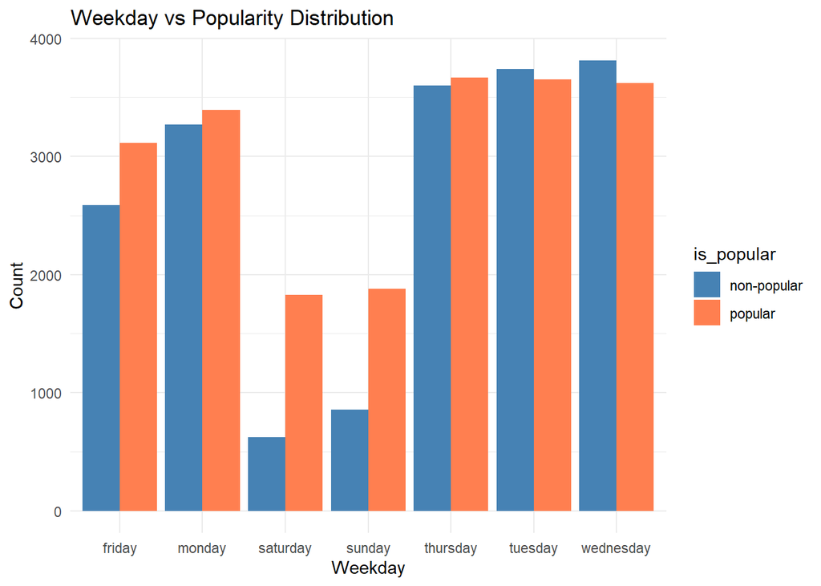

```r
# Plot the cross-tabulation of weekdays and popularity categories using ggplot2
cross_tab_popularity_plot <- ggplot(cross_tab_popularity_df, aes(x = weekday, y = count, fill = is_popular)) +
  geom_bar(stat = "identity", position = "dodge") +
  theme_minimal() +
  labs(title = "Weekday vs Popularity Distribution", x = "Weekday", y = "Count") +
  scale_fill_manual(values = c("non-popular" = "steelblue", "popular" = "coral"))
print(cross_tab_popularity_plot)
```

## Regression

Train and evaluate various regression algorithms, such as linear regression, random forests, and gradient boosting machines, to identify the best-performing model for predicting the number of shares. Select the best tuned model that you will use in final evaluations to report the test RMSPE and its uncertainty

Here I have chosen three models: 1) Linear regression 2) Random Forest 3) GBM

We will be calculating the RMSPE, mean RMSPE and standard deviation of RMSPE for each model and determine which model gives a more accurate prediction.

#Linear Regression

```r
n = 100
rmspe <- c()
for (i in 1: n){
  ind <- sample(nrow(df2_cleaned), nrow(df2_cleaned)*0.8)
  train <- df2_cleaned[ind, ]
  test <- df2_cleaned[-ind, ]
  # Suppress warnings for the lm() function
  suppressWarnings({
    # training the model
    model_lm <- lm(shares ~., data = train)
  })
  # prediction
  yhat <- predict(model_lm, test)
  # Accuracy metric
  rmspe[i] <- sqrt(mean((test$shares - yhat)^2))
}
```

[output not shown]

[output cut: 244 more lines]

[output not shown]

```r
# Calculate mean and standard deviation of rmspe
mean_rmspe_lm <- mean(rmspe)
sd_rmspe_lm <- sd(rmspe)

print(mean_rmspe_lm)
```

```
## [1] 11948.46
```

```r
print(sd_rmspe_lm)
```

```
## [1] 3249.957
```

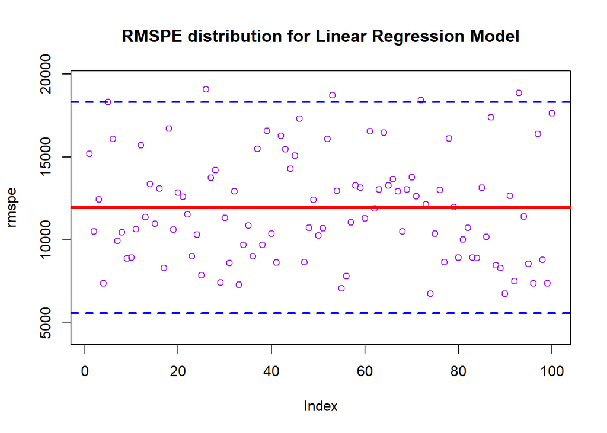

```r
# Confidence interval (assuming normal distribution)
lower <- mean_rmspe_lm - 1.96 * sd_rmspe_lm
upper <- mean_rmspe_lm + 1.96 * sd_rmspe_lm

# Plotting
plot(rmspe, col="purple", ylim = c(lower - 0.1*(upper-lower), upper + 0.1*(upper-lower)), main = "RMSPE distribution for Linear Regression Model")
abline(a = mean_rmspe_lm, b = 0, col="red", lwd = 3)
abline(a = lower, b = 0, col="blue", lwd = 2, lty = 2)
abline(a = upper, b = 0, col="blue", lwd = 2, lty = 2)
```

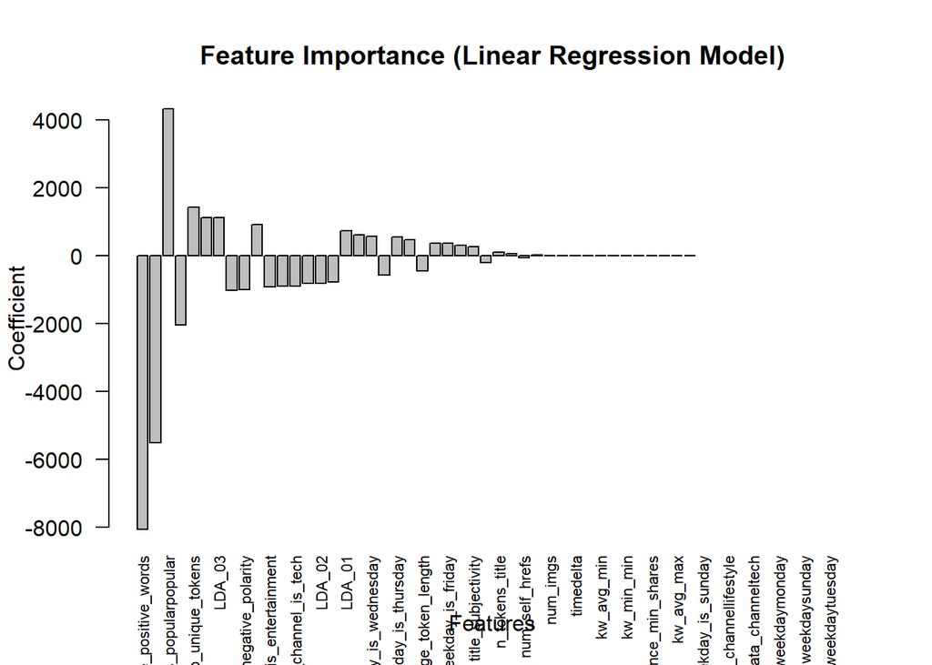

```r
# Extract coefficients and remove the intercept
coefficients_lm <- coef(model_lm)[-1]

# Sort the coefficients by their absolute values
sorted_coefficients_lm <- coefficients_lm[order(abs(coefficients_lm), decreasing = TRUE)]

# Plot the feature importance
barplot(sorted_coefficients_lm, main = "Feature Importance (Linear Regression Model)", xlab = "Features", ylab = "Coefficient", las = 2, cex.names = 0.7)
```

1.Coefficients: Outliers can greatly influence the estimated coefficients. They can potentially cause large shifts in the line of best fit, which would change the coefficients and potentially lead to incorrect conclusions about the relationship between the variables.

2. Significance Tests: Outliers can affect the results of significance tests. They can cause variables to appear significant when they are not, or cause variables to appear non-significant when they are.

3.Assumption Violation: Outliers can cause the assumptions of the linear regression model to be violated. For example, outliers can cause the residuals to not be normally distributed or to have non-constant variance, both of which are assumptions of the linear regression model.

The relative influence barplot indicates the importance of each variables in this model.

1.Magnitude: The length of each bar corresponds to the magnitude of the corresponding regression coefficient. This is a measure of how much the dependent variable (in your case, ‘shares’) is expected to increase or decrease when that variable increases by one unit, assuming all other variables are held constant.

2.Direction: The direction of each bar (positive or negative) corresponds to the sign of the coefficient. A positive bar indicates that the ‘shares’ is expected to increase when that variable increases, while a negative bar indicates that ‘shares’ is expected to decrease when that variable increases.

# Random Forest

```r
library(randomForest)
library(randomForestExplainer)
library(rpart)
n <- 5
B <- 10
RMSPERF <- c()
for (i in 1:n) {
  ind <- sample(nrow(df), nrow(df), replace = TRUE)
  train <- df[ind, ]
  test <- df[-ind, ]
  modelRF <- randomForest(shares~., ntree = B, data = train) # RF
  yhatRF <- predict(modelRF, test)
  RMSPERF[i] <- sqrt(mean((test$shares - yhatRF)^2))
}
mean(RMSPERF)
```

```
## [1] 12969.94
```

```r
mean_rmspe <- mean(RMSPERF)
sd_rmspe <- sd(RMSPERF)

print(mean_rmspe)
```

```
## [1] 12969.94
```

```r
print(sd_rmspe)
```

```
## [1] 944.01
```

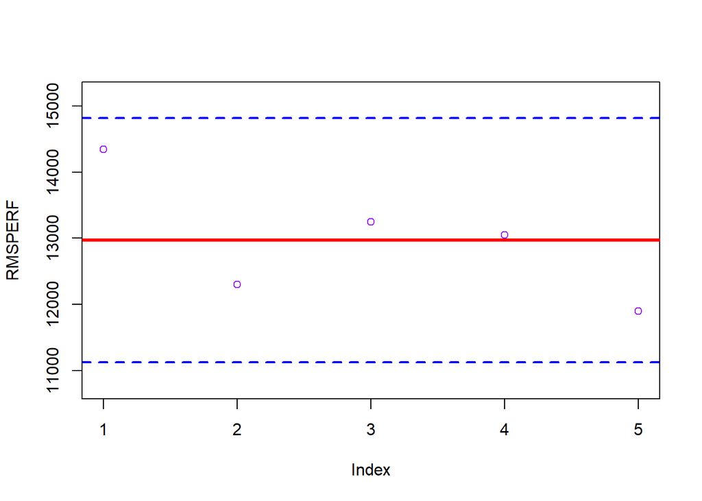

```r
# Confidence interval (assuming normal distribution)
lower <- mean_rmspe - 1.96 * sd_rmspe
upper <- mean_rmspe + 1.96 * sd_rmspe

# Plotting
plot(RMSPERF, col="purple", ylim = c(lower - 0.1*(upper-lower), upper + 0.1*(upper-lower)))
abline(a = mean_rmspe, b = 0, col="red", lwd = 3)
abline(a = lower, b = 0, col="blue", lwd = 2, lty = 2)
abline(a = upper, b = 0, col="blue", lwd = 2, lty = 2)
```

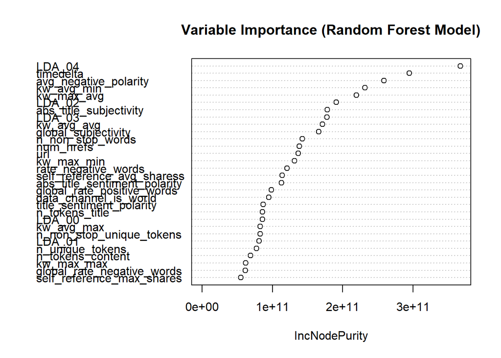

```r
# Variable importance plot for the random forest model (model3)
varImpPlot(modelRF, main = "Variable Importance (Random Forest Model)")
```

```r
min_depth_frame <- min_depth_distribution(modelRF)
importance_frame <- measure_importance(modelRF)
```

```
## [1] "Warning: your forest does not contain information on local importance so 'mse_increase' measure cannot be extracted. To add it regrow the forest with the option localImp = TRUE and run this function again."
```

```r
importance_frame
```

```
##                         variable mean_min_depth no_of_nodes
## 1   abs_title_sentiment_polarity            7.0        1533
## 2         abs_title_subjectivity            5.2        1877
## 3           average_token_length            5.3        3510
## 4          avg_negative_polarity            4.5        3231
## 5          avg_positive_polarity            5.0        3444
## 6            data_channel_is_bus           12.4         310
## 7  data_channel_is_entertainment           10.2         355
## 8      data_channel_is_lifestyle           10.2         175
## 9         data_channel_is_socmed            8.1         227
## 10          data_channel_is_tech            9.1         357
## 11         data_channel_is_world           10.3         310
## 12    global_rate_negative_words            4.6        3071
## 13    global_rate_positive_words            5.1        3135
## 14     global_sentiment_polarity            5.3        3159
```

[output cut: 107 more lines]

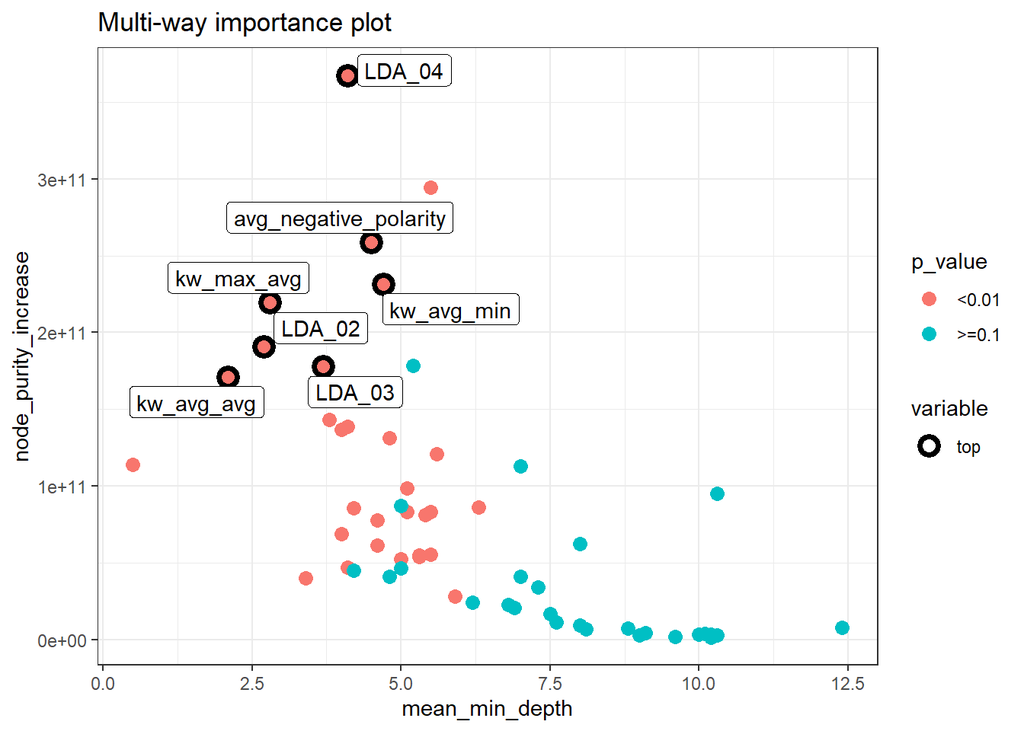

```r
plot_multi_way_importance(importance_frame, x_measure = "mean_min_depth",
                          y_measure = "node_purity_increase",
                          size_measure = "p_value", no_of_labels = 6)
```

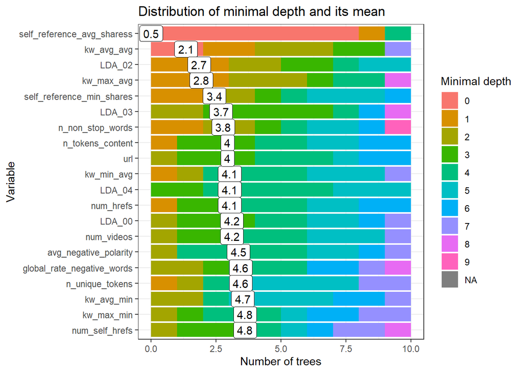

```r
plot_min_depth_distribution(min_depth_frame, mean_sample = "all_trees", k =20,
                            main = "Distribution of minimal depth and its mean")
```

Unfortunately I was unable to run more loops with more trees as my laptop was not cooperating. Note that once n and B increased the prediction above will be much better.

# GBM

```r
library(gbm)
df <- OnlineNewsPopularity
str(df)
```

```
## spc_tbl_ [39,644 × 61] (S3: spec_tbl_df/tbl_df/tbl/data.frame)
##  $ url                          : chr [1:39644] "http://mashable.com/2013/01/07/amazon-instant-video-browser/" "http://mashable.com/2013/01/07/ap-samsung-sponsored-tweets/" "http://mashable.com/2013/01/07/apple-40-billion-app-downloads/" "http://mashable.com/2013/01/07/astronaut-notre-dame-bcs/" …
##  $ timedelta                    : num [1:39644] 731 731 731 731 731 731 731 731 731 731 ...
##  $ n_tokens_title               : num [1:39644] 12 9 9 9 13 10 8 12 11 10 ...
##  $ n_tokens_content             : num [1:39644] 219 255 211 531 1072 ...
##  $ n_unique_tokens              : num [1:39644] 0.664 0.605 0.575 0.504 0.416 ...
##  $ n_non_stop_words             : num [1:39644] 1 1 1 1 1 ...
##  $ n_non_stop_unique_tokens     : num [1:39644] 0.815 0.792 0.664 0.666 0.541 ...
##  $ num_hrefs                    : num [1:39644] 4 3 3 9 19 2 21 20 2 4 ...
##  $ num_self_hrefs               : num [1:39644] 2 1 1 0 19 2 20 20 0 1 ...
##  $ num_imgs                     : num [1:39644] 1 1 1 1 20 0 20 20 0 1 ...
##  $ num_videos                   : num [1:39644] 0 0 0 0 0 0 0 0 0 1 ...
##  $ average_token_length         : num [1:39644] 4.68 4.91 4.39 4.4 4.68 ...
##  $ num_keywords                 : num [1:39644] 5 4 6 7 7 9 10 9 7 5 ...
##  $ data_channel_is_lifestyle    : num [1:39644] 0 0 0 0 0 0 1 0 0 0 ...
##  $ data_channel_is_entertainment: num [1:39644] 1 0 0 1 0 0 0 0 0 0 ...
##  $ data_channel_is_bus          : num [1:39644] 0 1 1 0 0 0 0 0 0 0 ...
##  $ data_channel_is_socmed       : num [1:39644] 0 0 0 0 0 0 0 0 0 0 ...
##  $ data_channel_is_tech         : num [1:39644] 0 0 0 0 1 1 0 1 1 0 ...
##  $ data_channel_is_world        : num [1:39644] 0 0 0 0 0 0 0 0 0 1 ...
##  $ kw_min_min                   : num [1:39644] 0 0 0 0 0 0 0 0 0 0 ...
##  $ kw_max_min                   : num [1:39644] 0 0 0 0 0 0 0 0 0 0 ...
##  $ kw_avg_min                   : num [1:39644] 0 0 0 0 0 0 0 0 0 0 ...
##  $ kw_min_max                   : num [1:39644] 0 0 0 0 0 0 0 0 0 0 ...
##  $ kw_max_max                   : num [1:39644] 0 0 0 0 0 0 0 0 0 0 ...
##  $ kw_avg_max                   : num [1:39644] 0 0 0 0 0 0 0 0 0 0 ...
##  $ kw_min_avg                   : num [1:39644] 0 0 0 0 0 0 0 0 0 0 ...
##  $ kw_max_avg                   : num [1:39644] 0 0 0 0 0 0 0 0 0 0 ...
##  $ kw_avg_avg                   : num [1:39644] 0 0 0 0 0 0 0 0 0 0 ...
##  $ self_reference_min_shares    : num [1:39644] 496 0 918 0 545 8500 545 545 0 0 ...
##  $ self_reference_max_shares    : num [1:39644] 496 0 918 0 16000 8500 16000 16000 0 0 ...
##  $ self_reference_avg_sharess   : num [1:39644] 496 0 918 0 3151 ...
##  $ weekday_is_monday            : num [1:39644] 1 1 1 1 1 1 1 1 1 1 ...
##  $ weekday_is_tuesday           : num [1:39644] 0 0 0 0 0 0 0 0 0 0 ...
##  $ weekday_is_wednesday         : num [1:39644] 0 0 0 0 0 0 0 0 0 0 ...
##  $ weekday_is_thursday          : num [1:39644] 0 0 0 0 0 0 0 0 0 0 ...
##  $ weekday_is_friday            : num [1:39644] 0 0 0 0 0 0 0 0 0 0 ...
##  $ weekday_is_saturday          : num [1:39644] 0 0 0 0 0 0 0 0 0 0 ...
##  $ weekday_is_sunday            : num [1:39644] 0 0 0 0 0 0 0 0 0 0 ...
##  $ is_weekend                   : num [1:39644] 0 0 0 0 0 0 0 0 0 0 ...
```

[output cut: 72 more lines]

```
##   ..   rate_positive_words = col_double(),
##   ..   rate_negative_words = col_double(),
##   ..   avg_positive_polarity = col_double(),
##   ..   min_positive_polarity = col_double(),
##   ..   max_positive_polarity = col_double(),
##   ..   avg_negative_polarity = col_double(),
##   ..   min_negative_polarity = col_double(),
##   ..   max_negative_polarity = col_double(),
##   ..   title_subjectivity = col_double(),
##   ..   title_sentiment_polarity = col_double(),
##   ..   abs_title_subjectivity = col_double(),
##   ..   abs_title_sentiment_polarity = col_double(),
##   ..   shares = col_double()
##   .. )
##  - attr(*, "problems")=<externalptr>
```

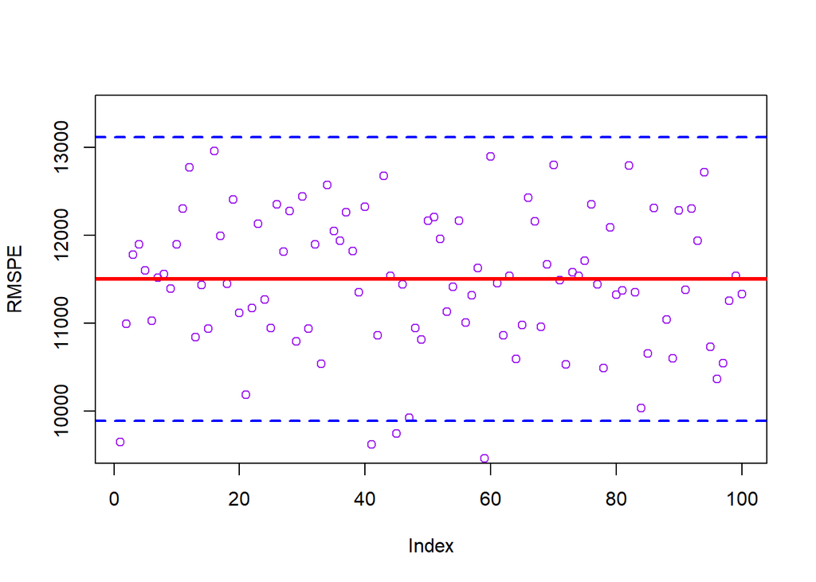

```r
df2 <- subset(df, select = -url)

# Remove rows with NAs
df2 <- df2[complete.cases(df), ]

# Convert character columns to factors
for (i in 1:ncol(df2)) {
  if(is.character(df2[, i])) df2[,i] <- as.factor(df2[,i])
}

# Grid search
h <- seq(0.01, 0.1, 0.01)
B <- c(1, 5, 10, 15, 20)
D <- 1:2
grid <- expand.grid(D = D, B = B, h = h)
grid$rmspe <- rep(0, nrow(grid))

# Calculate RMSPE for each combination of parameters
RMSPE <- c()
for(i in 1:nrow(grid)) {
  test_mse <- c()
  for (j in 1:5) {
    # Split into training and test sets
    ind <- sample(nrow(df2), nrow(df2), replace = TRUE)
    train <- df2[ind,]
    test <- df2[-ind,]

    # Train GBM model
    model.gbm <- gbm(
      shares ~ .,
      data = train,
      distribution = "gaussian",
      n.trees = grid[i, "B"],
      interaction.depth = grid[i, "D"],
      shrinkage = grid[i, "h"],
      bag.fraction = 1
    )

    # Calculate RMSPE for test set
    yhat <- predict(model.gbm, test, n.trees = grid[i, "B"])
    test_mse[j] <- mean((test$shares - yhat) ^ 2)
  }
  grid$rmspe[i] <- mean(test_mse)
  RMSPE[i] <- sqrt(mean(test_mse))
}

# Calculate mean and standard deviation of RMSPE
mean_rmspe <- mean(RMSPE)
sd_rmspe <- sd(RMSPE)

# Confidence interval (assuming normal distribution)
lower <- mean_rmspe - 1.96 * sd_rmspe
upper <- mean_rmspe + 1.96 * sd_rmspe

# Plot RMSPE with mean and confidence interval
plot(RMSPE, col="purple", ylim = c(lower - 0.1*(upper-lower), upper + 0.1*(upper-lower)))
abline(a = mean_rmspe, b = 0, col="red", lwd = 3)
abline(a = lower, b = 0, col="blue", lwd = 2, lty = 2)
abline(a = upper, b = 0, col="blue", lwd = 2, lty = 2)
```

```r
# Compute the relative influence of each feature
feature_importance_gbm <- summary(model.gbm)
```

[figure not shown]

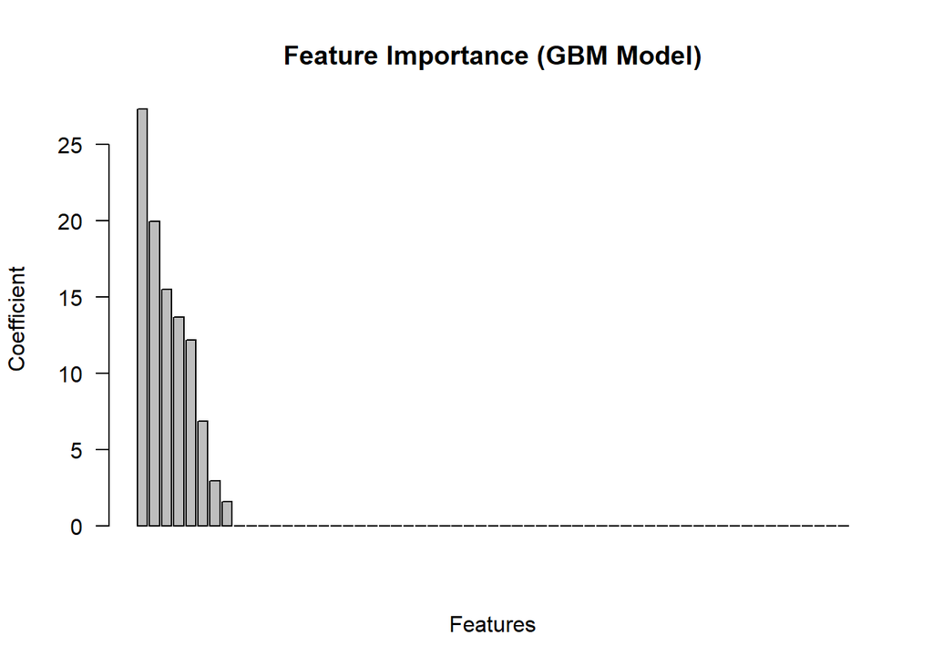

```r
# Plot the feature importance
barplot(feature_importance_gbm$rel.inf, main = "Feature Importance (GBM Model)", xlab = "Features", ylab = "Coefficient", las = 2, cex.names = 0.7)
```

```r
# Output mean and standard deviation of RMSPE
cat("Mean RMSPE:", mean_rmspe, "\n")
```

```
## Mean RMSPE: 11499.8
```

```r
cat("SD RMSPE:", sd_rmspe, "\n")
```

```
## SD RMSPE: 823.1996
```

Once again, since the gbm model with cross validation also takes a significant amount of time to run, I was unable to use larger B values and test different combinations of shrinkage value as well as run it for multiple loops.

## Classification

Interpreting the models for both regression and classification tasks is essential to understand the key features driving article popularity and provide actionable insights for content creators and marketers. To achieve this, you can follow these steps: • Feature importance analysis: Examine the importance of each feature in your best-performing models for both regression and classification tasks. Most machine learning algorithms, like random forests and gradient boosting machines provide methods to extract feature importance or coefficients. This information allows you to rank the features based on their contribution to the model’s performance. • Visualize feature importance: Create visualizations (e.g., bar charts) to represent the feature importance scores obtained from your models. This will help you effectively communicate the relative importance of each feature in predicting article popularity. • Inspect the confusion table: Analyze the classification model by inspecting the confusion table.

Here I have chosn the following models:

1. Logistic regression
2. Bagging
3. Random Forest
4. GBM

```r
library(ROCR)
library(rpart)
library(randomForest)
library(randomForestExplainer)

library(readr)
OnlineNewsPopularity <- read_csv("OnlineNewsPopularity.csv")
df <- OnlineNewsPopularity

str(df)
```

```
## spc_tbl_ [39,644 × 61] (S3: spec_tbl_df/tbl_df/tbl/data.frame)
##  $ url                          : chr [1:39644] "http://mashable.com/2013/01/07/amazon-instant-video-browser/" "http://mashable.com/2013/01/07/ap-samsung-sponsored-tweets/" "http://mashable.com/2013/01/07/apple-40-billion-app-downloads/" "http://mashable.com/2013/01/07/astronaut-notre-dame-bcs/" …
##  $ timedelta                    : num [1:39644] 731 731 731 731 731 731 731 731 731 731 ...
##  $ n_tokens_title               : num [1:39644] 12 9 9 9 13 10 8 12 11 10 ...
##  $ n_tokens_content             : num [1:39644] 219 255 211 531 1072 ...
##  $ n_unique_tokens              : num [1:39644] 0.664 0.605 0.575 0.504 0.416 ...
##  $ n_non_stop_words             : num [1:39644] 1 1 1 1 1 ...
##  $ n_non_stop_unique_tokens     : num [1:39644] 0.815 0.792 0.664 0.666 0.541 ...
##  $ num_hrefs                    : num [1:39644] 4 3 3 9 19 2 21 20 2 4 ...
##  $ num_self_hrefs               : num [1:39644] 2 1 1 0 19 2 20 20 0 1 ...
##  $ num_imgs                     : num [1:39644] 1 1 1 1 20 0 20 20 0 1 ...
##  $ num_videos                   : num [1:39644] 0 0 0 0 0 0 0 0 0 1 ...
##  $ average_token_length         : num [1:39644] 4.68 4.91 4.39 4.4 4.68 ...
##  $ num_keywords                 : num [1:39644] 5 4 6 7 7 9 10 9 7 5 ...
##  $ data_channel_is_lifestyle    : num [1:39644] 0 0 0 0 0 0 1 0 0 0 ...
##  $ data_channel_is_entertainment: num [1:39644] 1 0 0 1 0 0 0 0 0 0 ...
##  $ data_channel_is_bus          : num [1:39644] 0 1 1 0 0 0 0 0 0 0 ...
##  $ data_channel_is_socmed       : num [1:39644] 0 0 0 0 0 0 0 0 0 0 ...
##  $ data_channel_is_tech         : num [1:39644] 0 0 0 0 1 1 0 1 1 0 ...
##  $ data_channel_is_world        : num [1:39644] 0 0 0 0 0 0 0 0 0 1 ...
##  $ kw_min_min                   : num [1:39644] 0 0 0 0 0 0 0 0 0 0 ...
##  $ kw_max_min                   : num [1:39644] 0 0 0 0 0 0 0 0 0 0 ...
##  $ kw_avg_min                   : num [1:39644] 0 0 0 0 0 0 0 0 0 0 ...
##  $ kw_min_max                   : num [1:39644] 0 0 0 0 0 0 0 0 0 0 ...
##  $ kw_max_max                   : num [1:39644] 0 0 0 0 0 0 0 0 0 0 ...
##  $ kw_avg_max                   : num [1:39644] 0 0 0 0 0 0 0 0 0 0 ...
##  $ kw_min_avg                   : num [1:39644] 0 0 0 0 0 0 0 0 0 0 ...
##  $ kw_max_avg                   : num [1:39644] 0 0 0 0 0 0 0 0 0 0 ...
##  $ kw_avg_avg                   : num [1:39644] 0 0 0 0 0 0 0 0 0 0 ...
##  $ self_reference_min_shares    : num [1:39644] 496 0 918 0 545 8500 545 545 0 0 ...
##  $ self_reference_max_shares    : num [1:39644] 496 0 918 0 16000 8500 16000 16000 0 0 ...
##  $ self_reference_avg_sharess   : num [1:39644] 496 0 918 0 3151 ...
##  $ weekday_is_monday            : num [1:39644] 1 1 1 1 1 1 1 1 1 1 ...
##  $ weekday_is_tuesday           : num [1:39644] 0 0 0 0 0 0 0 0 0 0 ...
##  $ weekday_is_wednesday         : num [1:39644] 0 0 0 0 0 0 0 0 0 0 ...
##  $ weekday_is_thursday          : num [1:39644] 0 0 0 0 0 0 0 0 0 0 ...
##  $ weekday_is_friday            : num [1:39644] 0 0 0 0 0 0 0 0 0 0 ...
##  $ weekday_is_saturday          : num [1:39644] 0 0 0 0 0 0 0 0 0 0 ...
##  $ weekday_is_sunday            : num [1:39644] 0 0 0 0 0 0 0 0 0 0 ...
##  $ is_weekend                   : num [1:39644] 0 0 0 0 0 0 0 0 0 0 ...
```

[output cut: 72 more lines]

```
##   ..   rate_positive_words = col_double(),
##   ..   rate_negative_words = col_double(),
##   ..   avg_positive_polarity = col_double(),
##   ..   min_positive_polarity = col_double(),
##   ..   max_positive_polarity = col_double(),
##   ..   avg_negative_polarity = col_double(),
##   ..   min_negative_polarity = col_double(),
##   ..   max_negative_polarity = col_double(),
##   ..   title_subjectivity = col_double(),
##   ..   title_sentiment_polarity = col_double(),
##   ..   abs_title_subjectivity = col_double(),
##   ..   abs_title_sentiment_polarity = col_double(),
##   ..   shares = col_double()
##   .. )
##  - attr(*, "problems")=<externalptr>
```

```r
df3 <- subset(df, select = -url)

which(is.na(df3))
```

```
## integer(0)
```

```r
df3 <- df3[complete.cases(df), ]

for (i in 1:ncol(df3)) {
  if(is.character(df3[, i])) df[,i] <- as.factor(df3[,i])
}
df3$shares <- ifelse(df3$shares >= 3395, 1, 0)
df3$shares <- factor(df3$shares, levels = c("1", "0"))

# Split data into training and test sets

df3 <- df3[complete.cases(df3$shares), ]

n <- 10
B <- 10
AUC1 <- c()
AUC2 <- c()
AUC3 <- c()
for (i in 1:n) {
  ind <- sample(nrow(df3), nrow(df3), replace = TRUE)
  train2 <- df3[ind, ]
  test2 <- df3[-ind, ]
  p = ncol(train2)-1

  model1 <- glm(shares ~ ., family = binomial(link = "logit"), data = train2)

  model2 <- randomForest(shares~.,
                         ntree = B, mtry = p, data = train2) #Bagged
  model3 <- randomForest(shares~.,
                         ntree = B, data = train2) # RF
  phat1 <- predict(model1, test2, type = "response")
  phat2 <- predict(model2, test2, type = "prob")
  phat3 <- predict(model3, test2, type = "prob")
  #AUC1
  pred_rocr1 <- prediction(phat1, as.numeric(as.character(test2$shares)))
  auc_ROCR1 <- performance(pred_rocr1, measure = "auc")
  AUC1[i] <- auc_ROCR1@y.values[[1]]
  #AUC2
  pred_rocr2 <- prediction(phat2[,2], test2$shares)
  auc_ROCR2 <- performance(pred_rocr2, measure = "auc")
  AUC2[i] <- auc_ROCR2@y.values[[1]]
  #AUC3
  pred_rocr3 <- prediction(phat3[,2], test2$shares)
  auc_ROCR3 <- performance(pred_rocr3, measure = "auc")
  AUC3[i] <- auc_ROCR3@y.values[[1]]
}
```

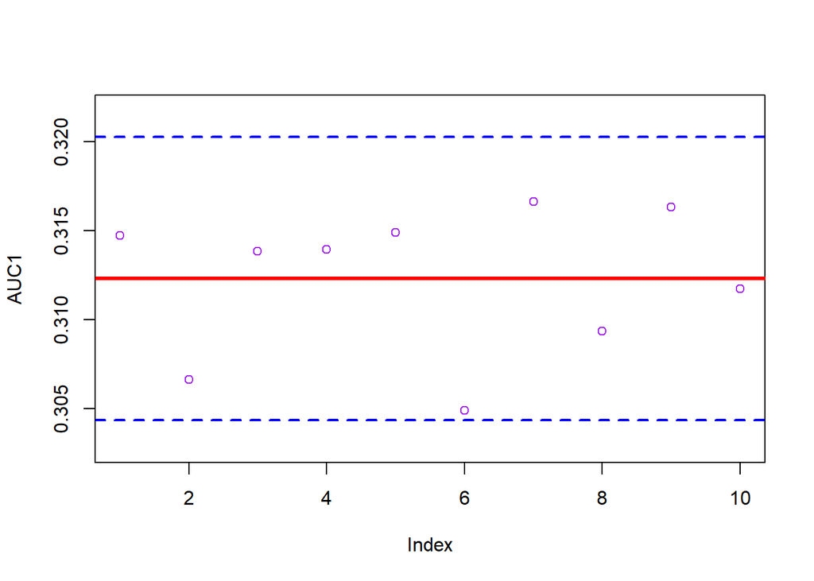

```r
mean_AUC1 <- mean(AUC1)
sd_AUC1 <- sd(AUC1)

# Confidence interval (assuming normal distribution)
lower <- mean_AUC1 - 1.96 * sd_AUC1
upper <- mean_AUC1 + 1.96 * sd_AUC1

# Plotting
plot(AUC1, col="purple", ylim = c(lower - 0.1*(upper-lower), upper + 0.1*(upper-lower)))
abline(a = mean_AUC1, b = 0, col="red", lwd = 3)
abline(a = lower, b = 0, col="blue", lwd = 2, lty = 2)
abline(a = upper, b = 0, col="blue", lwd = 2, lty = 2)
```

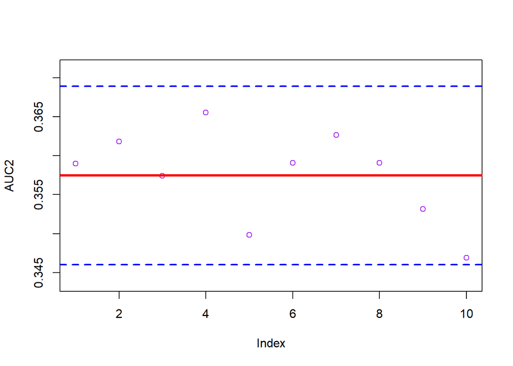

```r
mean_AUC2 <- mean(AUC2)
sd_AUC2 <- sd(AUC2)

# Confidence interval (assuming normal distribution)
lower <- mean_AUC2 - 1.96 * sd_AUC2
upper <- mean_AUC2 + 1.96 * sd_AUC2

# Plotting
plot(AUC2, col="purple", ylim = c(lower - 0.1*(upper-lower), upper + 0.1*(upper-lower)))
abline(a = mean_AUC2, b = 0, col="red", lwd = 3)
abline(a = lower, b = 0, col="blue", lwd = 2, lty = 2)
abline(a = upper, b = 0, col="blue", lwd = 2, lty = 2)
```

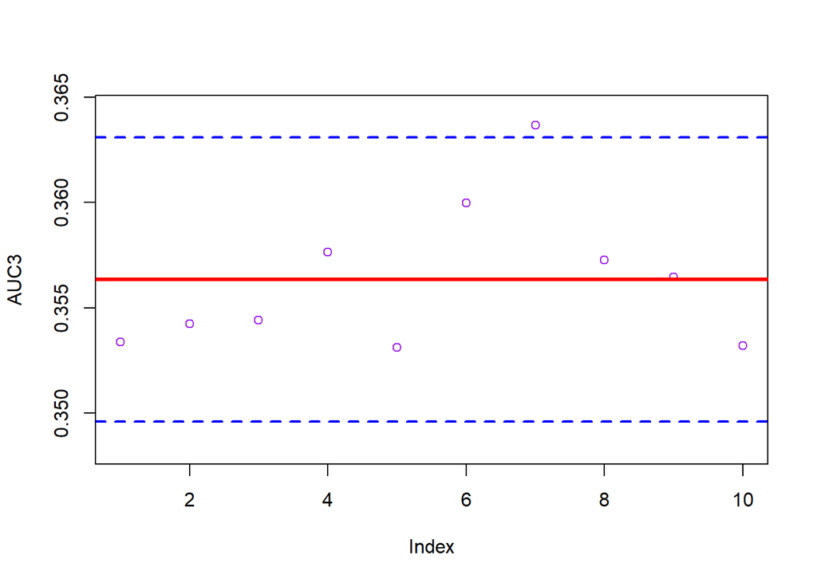

```r
mean_AUC3 <- mean(AUC3)
sd_AUC3 <- sd(AUC3)

# Confidence interval (assuming normal distribution)
lower <- mean_AUC3 - 1.96 * sd_AUC3
upper <- mean_AUC3 + 1.96 * sd_AUC3

# Plotting
plot(AUC3, col="purple", ylim = c(lower - 0.1*(upper-lower), upper + 0.1*(upper-lower)))
abline(a = mean_AUC3, b = 0, col="red", lwd = 3)
abline(a = lower, b = 0, col="blue", lwd = 2, lty = 2)
abline(a = upper, b = 0, col="blue", lwd = 2, lty = 2)
```

For this classification problem we will be using AUC to measure the accuracy of the models.

However with the result obtained we can conclude that Bagging was the better model out of the three.

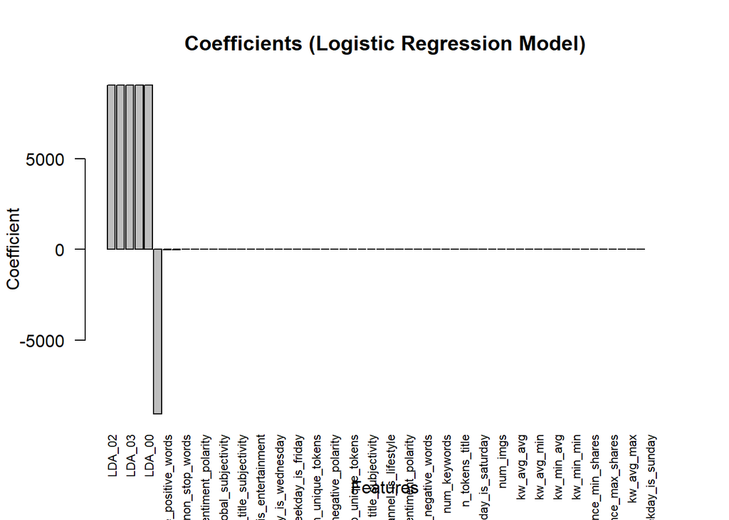

```r
# Extract coefficients for the logistic regression model
coefficients_glm <- coef(model1)

# Sort the coefficients by their absolute values
sorted_coefficients_glm <- coefficients_glm[order(abs(coefficients_glm), decreasing = TRUE)]

# Plot the coefficients
barplot(sorted_coefficients_glm, main = "Coefficients (Logistic Regression Model)", xlab = "Features", ylab = "Coefficient", las = 2, cex.names = 0.7)
```

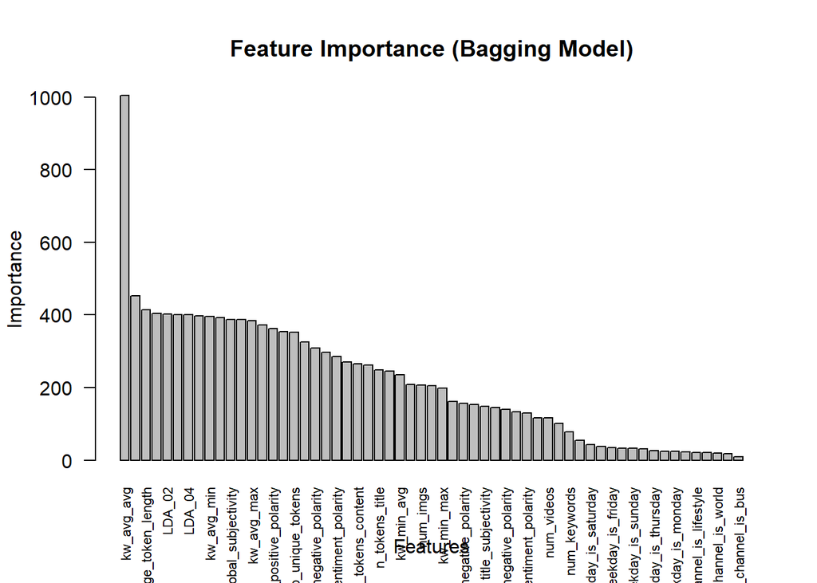

```r
library(randomForestExplainer)

# Extract feature importance for the random forest model
importance_bagging <- importance(model2)


# Sort the features by their importance
sorted_importance_bagging <- importance_bagging[order(importance_bagging, decreasing = TRUE),]
# Plot the feature importance
barplot(sorted_importance_bagging, main = "Feature Importance (Bagging Model)", xlab = "Features", ylab = "Importance", las = 2, cex.names = 0.7)
```

```r
# Predict on the test set using the random forest model
predictions_bagging <- predict(model3, test2, type = "class")

# Create a confusion table
confusion_table <- table(Predicted = predictions_bagging, Actual = test2$shares)
print(confusion_table)
```

```
##          Actual
## Predicted     1     0
##         1   466   750
##         0  2465 10923
```

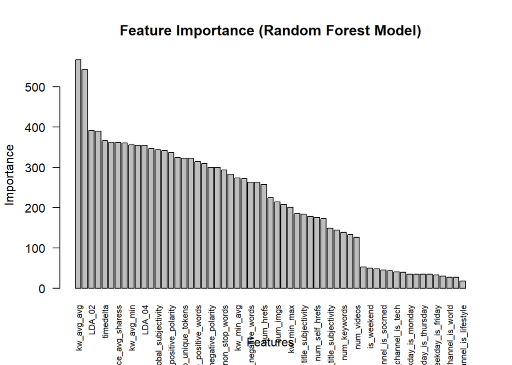

```r
# Extract feature importance for the random forest model
importance_rf <- importance(model3)

# Sort the features by their importance
sorted_importance_rf <- importance_rf[order(importance_rf, decreasing = TRUE),]
# Plot the feature importance
barplot(sorted_importance_rf, main = "Feature Importance (Random Forest Model)", xlab = "Features", ylab = "Importance", las = 2, cex.names = 0.7)
```

```r
# Predict on the test set using the random forest model
predictions_rf <- predict(model3, test2, type = "class")

# Create a confusion table
confusion_table <- table(Predicted = predictions_rf, Actual = test2$shares)
print(confusion_table)
```

```
##          Actual
## Predicted     1     0
##         1   461   767
##         0  2470 10906
```

While bagging and random Forest have as the most important feature Key Words average.

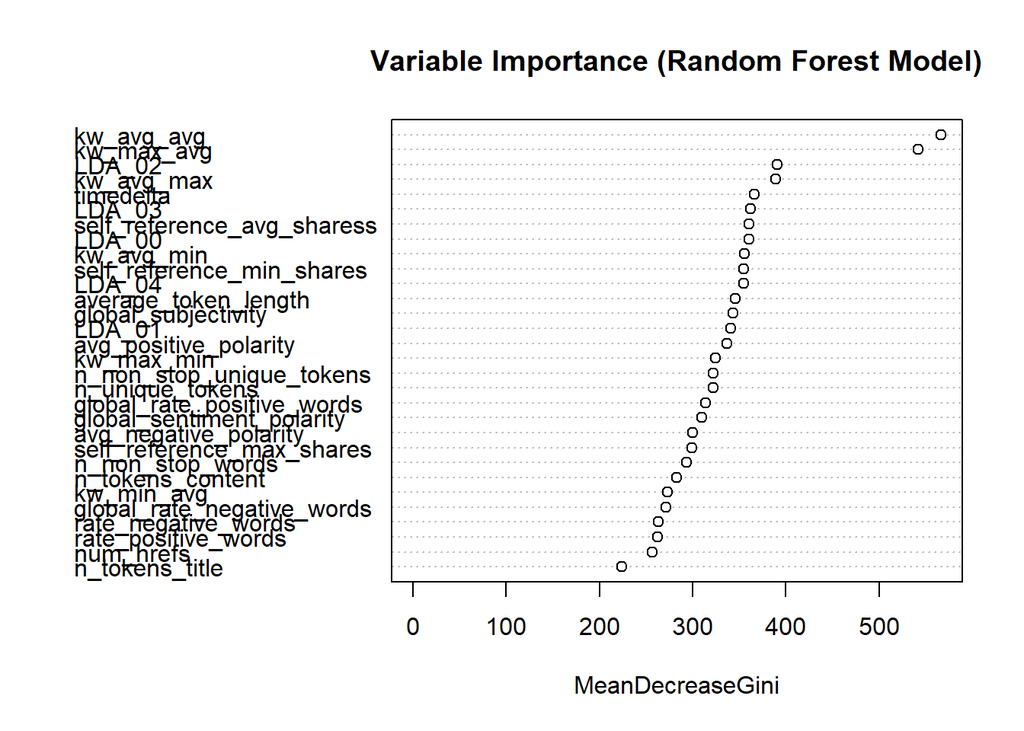

```r
# Load the randomForest package
library(randomForest)

# Variable importance plot for the random forest model (model3)
varImpPlot(model3, main = "Variable Importance (Random Forest Model)")
```

```r
min_depth_frame <- min_depth_distribution(model3)
importance_frame <- measure_importance(model3)
```

```
## [1] "Warning: your forest does not contain information on local importance so 'accuracy_decrease' measure cannot be extracted. To add it regrow the forest with the option localImp = TRUE and run this function again."
```

```r
importance_frame
```

```
##                         variable mean_min_depth no_of_nodes gini_decrease
## 1   abs_title_sentiment_polarity            4.9         527     172.06893
## 2         abs_title_subjectivity            5.8         504     148.57238
## 3           average_token_length            4.5         985     345.93176
## 4          avg_negative_polarity            4.9         889     300.07191
## 5          avg_positive_polarity            5.3         963     336.54154
## 6            data_channel_is_bus            8.8          94      26.70016
## 7  data_channel_is_entertainment            6.9         103      34.29944
## 8      data_channel_is_lifestyle            9.3          68      17.93662
## 9         data_channel_is_socmed            7.0         107      44.81613
## 10          data_channel_is_tech            7.8         133      40.58273
## 11         data_channel_is_world            6.8          74      27.26452
## 12    global_rate_negative_words            5.3         859     271.39877
## 13    global_rate_positive_words            4.9         922     314.13687
## 14     global_sentiment_polarity            4.9         922     309.48878
```

[output cut: 105 more lines]

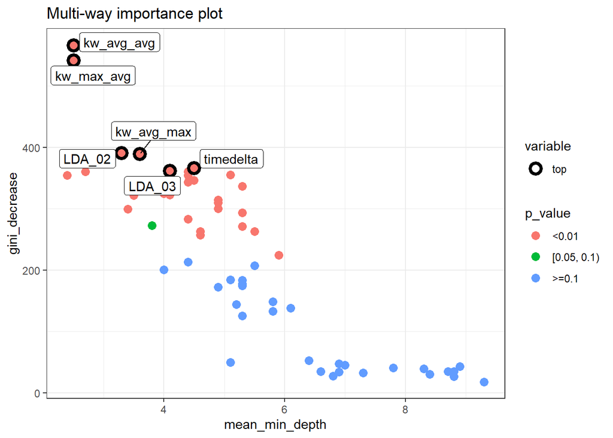

```r
plot_multi_way_importance(importance_frame, x_measure = "mean_min_depth",
                          y_measure = "gini_decrease",
                          size_measure = "p_value", no_of_labels = 6)
```

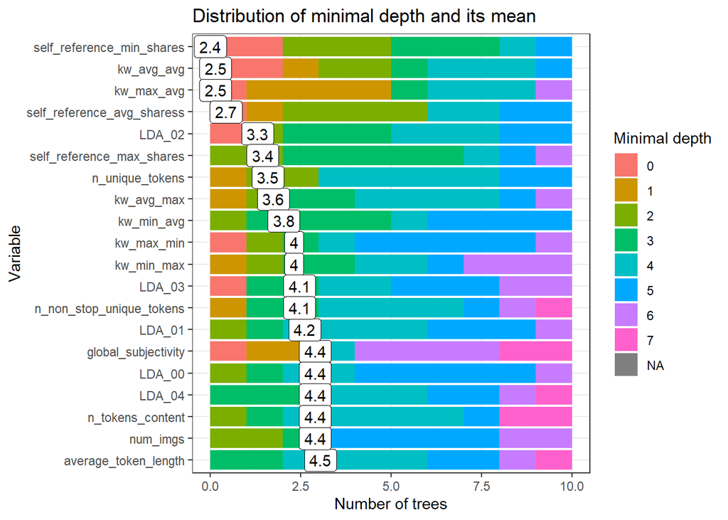

```r
plot_min_depth_distribution(min_depth_frame, mean_sample = "all_trees", k =20,
                            main = "Distribution of minimal depth and its mean")
```

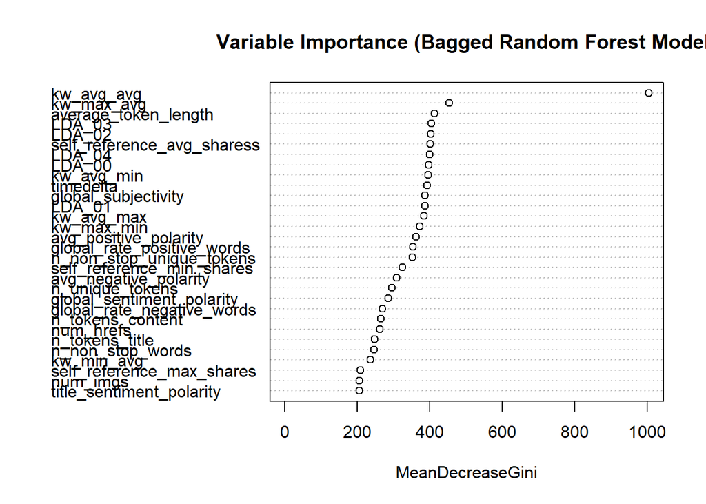

```r
# Variable importance plot for the bagged random forest model (model2)
varImpPlot(model2, main = "Variable Importance (Bagged Random Forest Model)")
```

```r
min_depth_frame <- min_depth_distribution(model2)
importance_frame <- measure_importance(model2)
```

```
## [1] "Warning: your forest does not contain information on local importance so 'accuracy_decrease' measure cannot be extracted. To add it regrow the forest with the option localImp = TRUE and run this function again."
```

```r
importance_frame
```

```
##                         variable mean_min_depth no_of_nodes gini_decrease
## 1   abs_title_sentiment_polarity            5.1         269     129.18443
## 2         abs_title_subjectivity            6.0         334     133.40151
## 3           average_token_length            4.7         932     413.54275
## 4          avg_negative_polarity            5.3         686     309.52320
## 5          avg_positive_polarity            5.0         798     363.16964
## 6            data_channel_is_bus           11.5          35      10.27263
## 7  data_channel_is_entertainment            8.7          58      25.03604
## 8      data_channel_is_lifestyle            9.5          75      21.67218
## 9         data_channel_is_socmed            4.1          97      54.46715
## 10          data_channel_is_tech            6.9          53      30.63200
## 11         data_channel_is_world            9.0          48      19.82053
## 12    global_rate_negative_words            5.3         629     270.07864
## 13    global_rate_positive_words            5.2         804     354.41769
## 14     global_sentiment_polarity            4.6         625     285.00748
```

[output cut: 105 more lines]

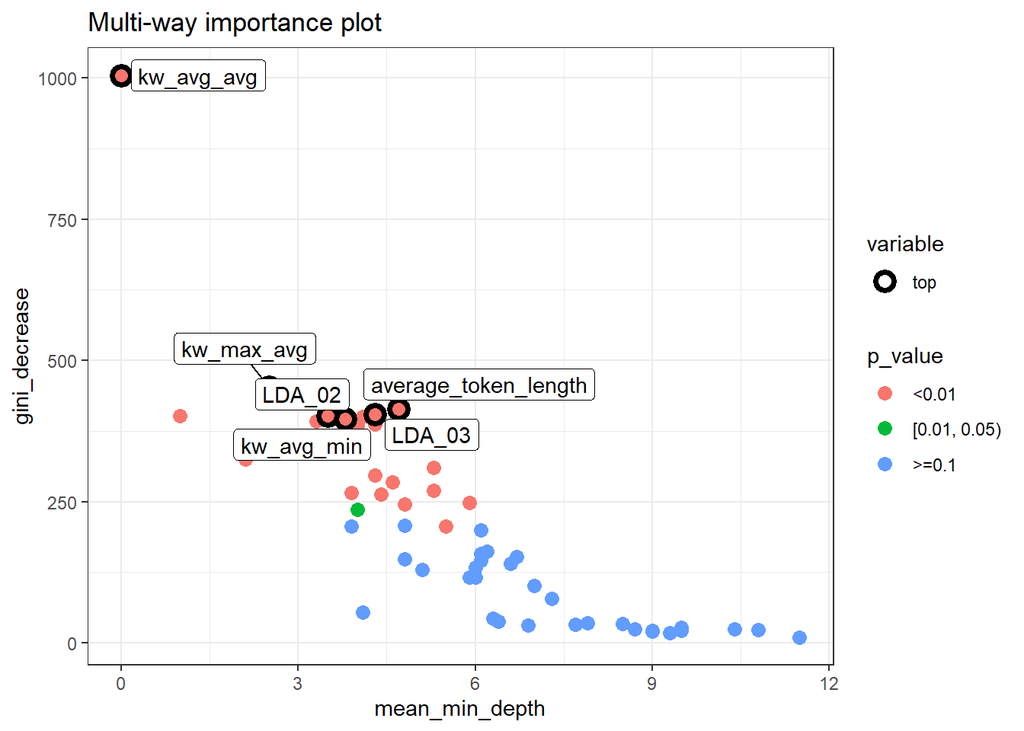

```r
plot_multi_way_importance(importance_frame, x_measure = "mean_min_depth",
                          y_measure = "gini_decrease",
                          size_measure = "p_value", no_of_labels = 6)
```

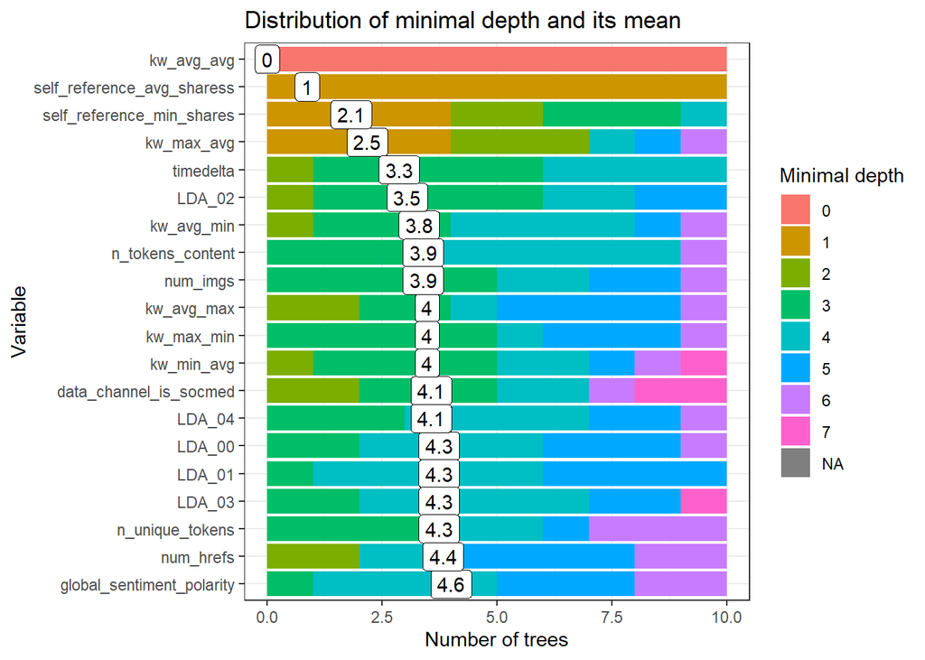

```r
plot_min_depth_distribution(min_depth_frame, mean_sample = "all_trees", k =20,
                            main = "Distribution of minimal depth and its mean")
```

Multi-way Importance Plot: This plot shows the relationship between multiple measures of variable importance. In this case, it shows the relationship between the mean minimal depth of a variable in the trees (a measure of how early in the trees the variable tends to split the data), and the Gini decrease, which is a measure of how much each variable contributes to the homogeneity of the nodes and leaves in the resulting Random Forest.

Minimal Depth Distribution Plot: This plot shows the distribution of the minimal depth of each variable in the trees of the Random Forest. The minimal depth of a variable is the depth at which the variable first splits the data in each tree. A lower minimal depth indicates that the variable is more important, because it is used to make decisions earlier in the trees.

The plot shows the distribution of the minimal depth across all the trees for each variable, and also shows the mean minimal depth. This can give you an idea of not only which variables are important on average, but also how much the importance of each variable varies across different trees in the forest.

As we can see from the plots above the variable that is the most important on average is Keywords average

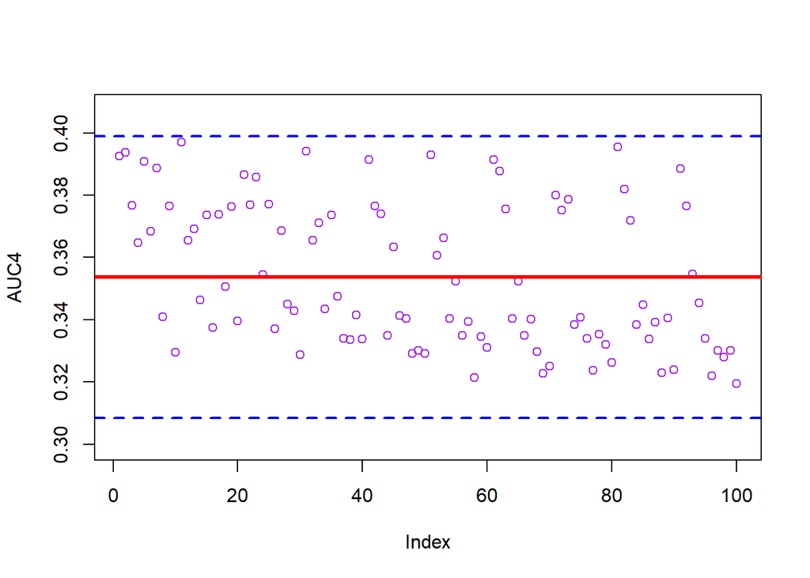

```r
library(gbm)

# Remove rows with NAs
df3 <- df3[complete.cases(df3), ]

# Convert character columns to factors
for (i in 1:ncol(df3)) {
  if(is.character(df3[, i])) df3[,i] <- as.factor(df3[,i])
}

# Grid search
h <- seq(0.01, 0.1, 0.01)
B <- c(1, 5, 10, 15, 20)
D <- 1:2
grid <- expand.grid(D = D, B = B, h = h)
grid$AUC4 <- rep(0, nrow(grid))

# Calculate RMSPE for each combination of parameters
AUC4 <- c()
for(i in 1:nrow(grid)) {
  test_mse <- c()
  for (j in 1:5) {
    # Split into training and test sets
    ind <- sample(nrow(df3), nrow(df3), replace = TRUE)
    train <- df3[ind,]
    test <- df3[-ind,]

    # Train GBM model
    model.gbm <- gbm(
      shares ~ .,
      data = train,
      distribution = "gaussian",
      n.trees = grid[i, "B"],
      interaction.depth = grid[i, "D"],
      shrinkage = grid[i, "h"],
      bag.fraction = 1
    )

    # Calculate RMSPE for test set
    phat4 <- predict(model.gbm, test, n.trees = grid[i, "B"])
    pred_rocr4 <- prediction(phat4, as.numeric(as.character(test$shares)))
    auc_ROCR4 <- performance(pred_rocr4, measure = "auc")
    AUC4[i] <- auc_ROCR4@y.values[[1]]
  }

}

mean_AUC4 <- mean(AUC4)
sd_AUC4 <- sd(AUC4)

# Confidence interval (assuming normal distribution)
lower <- mean_AUC4 - 1.96 * sd_AUC4
upper <- mean_AUC4 + 1.96 * sd_AUC4

# Plotting
plot(AUC4, col="purple", ylim = c(lower - 0.1*(upper-lower), upper + 0.1*(upper-lower)))
abline(a = mean_AUC4, b = 0, col="red", lwd = 3)
abline(a = lower, b = 0, col="blue", lwd = 2, lty = 2)
abline(a = upper, b = 0, col="blue", lwd = 2, lty = 2)
```

```r
# Compute the relative influence of each feature
feature_importance_gbm <- summary(model.gbm)
```

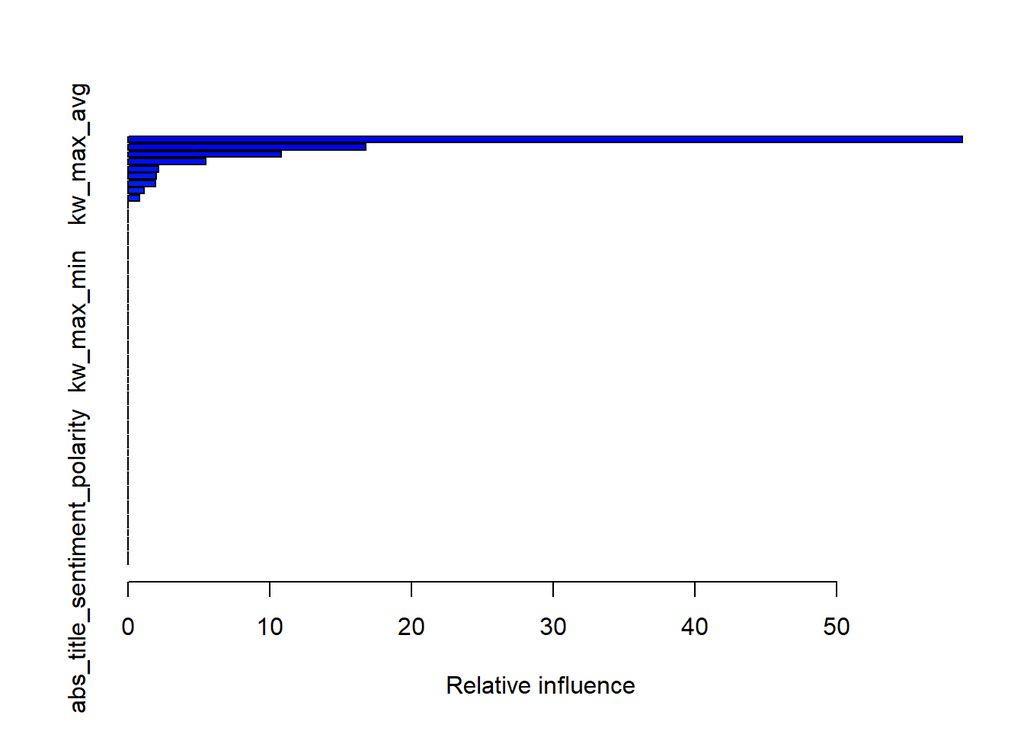

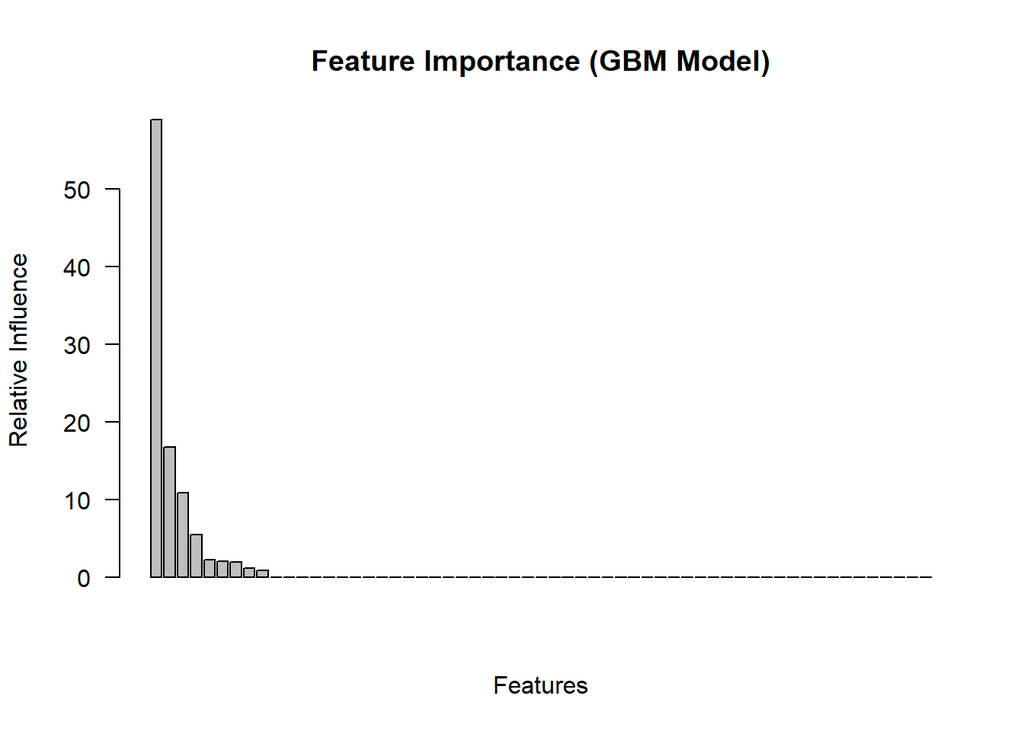

```r
# Plot the feature importance
barplot(
  feature_importance_gbm$rel.inf,
  main = "Feature Importance (GBM Model)",
  xlab = "Features",
  ylab = "Relative Influence",
  las = 2,
  cex.names = 0.7)
```

```r
# Output mean and standard deviation of RMSPE
cat("Mean AUC4:", mean_rmspe, "\n")
```

[output not shown]

```r
cat("SD AUC4:", sd_rmspe, "\n")
```

[output not shown]